# Project Final Report (project group 8)

### -Lijun Yang, Ruoyi Li, Yuheng Zhong

## Project Objectives:

Our project is to analyze status of operation for Taxi in New York City from different aspects of inspection. First, our goal is to explore whether some external factors, like weather, time span, season, and different areas, may affect the demand of Taxi in NYC. Second, our team is going to find the change of number of taxi ride in NYC along the day according to different areas. Finally, we will analyze the distribution of demand and weekly revenue.

By doing this analysis, we will have a clearly taxi market demand distribution map in different time period, weekday, holidays, different seasons, and different weather. For taxi driver’s perspective, we hope that we can provide them a reference that where and when they should go can pick up more customers and make more revenue. It also provides customers a reference about rush hour duration and which area might has a heavy traffic during the rush hours.

## Data Description

In this project, we are going to employ two datasets related to NYC taxi analysis.

The first one is NYC taxi trip descriptive dataset in 2016 with 16 million records published at NYC open data official website(https://data.cityofnewyork.us/Transportation/2016-Green-Taxi-Trip-Data/hvrh-b6nb). There are 23 fields available such as pickup longitude/latitude, drop off longitude/latitude, pickup datetime, drop off datetime, total_amount_fee, passenger cout and trip distance in the dataset. We want to figure out the relationship between NYC taxi demand and other factors the dataset provides.

## Progress Summary:

1. Clean taxi data
   - find and select any outliers and drop them
   - find any missing data
   - change string columns to numerical
   - drop any meaningless columns
2. Clean weather data
   - drop any meaningless columns
   - change string columns to numerical
   - extract useful infomation from weather description
3. Merge data
   - group weather data by day
   - group weather data by hour
   - group taxi data by day
   - group taxi data by hour
   - merge taxi and weather data
4. Data visualization
   - create bar chart for demand by hours
   - create bar chart for distance by hours
   - create scatter plot for demand by days
   - create scatter plot for demand by weathers
   - create scatter plot for demand by seasons
   - explain each graph
5. Demand Distrubution Analysis
   - create scatter plot for demand distrubution analysis
   - create geographic map for pickup & dropoff area analysis
6. Weekly Revenue Analysis
   - find any factors that influence revenue
7. Conclusion

## Question:

1. Does weather make effects on taxi demand?
2. How taxi revenue changes seasonally?
3. How demand and average distance of trips change hourly?
4. Which area shows a high demand in different time period?
5. Which area is the most popular destination?
6. What is the trend of weekly revenue in 2016?

## Direction of Analysis:

In our project, all research and analysis should focus on how taxi demand changes in NYC.

Firstly, we will focus on analyzing the relationship between taxi demand and other external factors such as temperature, precipitation, snow fall. Several seaborn visualization graphs will be built to support the analysis.

Secondly, we will build serveral charts to analyze the relationship between demand in specific area and different time period, so that we can know which area has high taxi demand during the communting time, lunch time, dinner time, and midnight time. What is more, we are going to build barplots to find the impilict relationship between demand, average distance and different time in a day.

The last but not the least, we will focus on analysis distrubution difference between working day and holiday, and geographic distrubution of pickup and dropoff records.

## Coding

```python
import pandas as pd
import datetime
import numpy as np
import seaborn as sns
import matplotlib
import matplotlib.pyplot as plt
```

## Read 2016 NYC taxi dataset

```python
#read taxi data
taxi_raw = pd.read_csv('/Users/reggieyang/Desktop/Python/Python Project/Dataset/2016_Green_Taxi_Trip_Data.csv')
```

```python
#taxi data shape
taxi_raw.shape
```

```
(16385532, 23)
```

```python
#create copy file, check head
taxi = taxi_raw.copy()
taxi.head()
```

|  | VendorID | lpep_pickup_datetime | Lpep_dropoff_datetime | Store_and_fwd_flag | RateCodeID | Pickup_longitude | Pickup_latitude | Dropoff_longitude | Dropoff_latitude | Passenger_count | ... | MTA_tax | Tip_amount | Tolls_amount | Ehail_fee | improvement_surcharge | Total_amount | Payment_type | Trip_type | PULocationID | DOLocationID |
| --- | --- | --- | --- | --- | --- | --- | --- | --- | --- | --- | --- | --- | --- | --- | --- | --- | --- | --- | --- | --- | --- |
| 0 | 2 | 03/24/2016 11:14:54 AM | 03/24/2016 11:20:54 AM | N | 1 | -73.953606 | 40.822086 | -73.960876 | 40.809982 | 1 | ... | 0.5 | 1.36 | 0.00 | NaN | 0.3 | 8.16 | 1 | 1.0 | NaN | NaN |
| 1 | 2 | 03/24/2016 11:08:43 AM | 03/24/2016 11:14:18 AM | N | 1 | -73.966606 | 40.804276 | -73.974014 | 40.791592 | 1 | ... | 0.5 | 0.00 | 0.00 | NaN | 0.3 | 6.80 | 2 | 1.0 | NaN | NaN |
| 2 | 2 | 03/24/2016 11:26:11 AM | 03/24/2016 11:42:36 AM | N | 1 | -73.966530 | 40.804249 | -73.939430 | 40.805172 | 1 | ... | 0.5 | 1.50 | 0.00 | NaN | 0.3 | 14.80 | 1 | 1.0 | NaN | NaN |
| 3 | 2 | 03/24/2016 11:45:05 AM | 03/24/2016 11:55:36 AM | N | 1 | -73.936951 | 40.804123 | -73.872467 | 40.774296 | 1 | ... | 0.5 | 0.00 | 5.54 | NaN | 0.3 | 24.84 | 1 | 1.0 | NaN | NaN |
| 4 | 2 | 03/24/2016 11:01:44 AM | 03/24/2016 11:09:00 AM | N | 1 | -73.938347 | 40.796387 | -73.949059 | 40.794273 | 1 | ... | 0.5 | 0.00 | 0.00 | NaN | 0.3 | 7.30 | 2 | 1.0 | NaN | NaN |

5 rows × 23 columns

## 1. Clean taxi data

```python
#describe column data, check if there are some outliers
taxi.describe()
```

|  | VendorID | RateCodeID | Pickup_longitude | Pickup_latitude | Dropoff_longitude | Dropoff_latitude | Passenger_count | Trip_distance | Fare_amount | Extra | MTA_tax | Tip_amount | Tolls_amount | Ehail_fee | improvement_surcharge | Total_amount | Payment_type | Trip_type | PULocationID | DOLocationID |
| --- | --- | --- | --- | --- | --- | --- | --- | --- | --- | --- | --- | --- | --- | --- | --- | --- | --- | --- | --- | --- |
| count | 1.638553e+07 | 1.638553e+07 | 9.018030e+06 | 9.018030e+06 | 9.018030e+06 | 9.018030e+06 | 1.638553e+07 | 1.638553e+07 | 1.638553e+07 | 1.638553e+07 | 1.638553e+07 | 1.638553e+07 | 1.638553e+07 | 0.0 | 1.638553e+07 | 1.638553e+07 | 1.638553e+07 | 1.638506e+07 | 7.367502e+06 | 7.367502e+06 |
| mean | 1.790590e+00 | 1.094279e+00 | -7.381650e+01 | 4.067972e+01 | -7.383075e+01 | 4.068654e+01 | 1.357557e+00 | 2.802718e+00 | 1.213675e+01 | 3.522082e-01 | 4.867317e-01 | 1.243873e+00 | 1.103113e-01 | NaN | 2.921152e-01 | 1.464115e+01 | 1.514710e+00 | 1.021329e+00 | 1.146251e+02 | 1.294281e+02 |
| std | 4.068873e-01 | 7.891883e-01 | 3.013607e+00 | 1.655605e+00 | 2.815466e+00 | 1.546043e+00 | 1.024279e+00 | 2.941111e+00 | 1.027957e+01 | 3.818636e-01 | 8.618982e-02 | 2.559969e+00 | 1.073319e+00 | NaN | 5.137505e-02 | 1.173573e+01 | 5.253130e-01 | 1.444797e-01 | 7.706517e+01 | 7.737860e+01 |
| min | 1.000000e+00 | 1.000000e+00 | -1.152825e+02 | 0.000000e+00 | -1.153322e+02 | 0.000000e+00 | 0.000000e+00 | 0.000000e+00 | -4.990000e+02 | -4.500000e+00 | -5.000000e-01 | -6.000000e+01 | -5.000000e+01 | NaN | -3.000000e-01 | -4.990000e+02 | 1.000000e+00 | 1.000000e+00 | 1.000000e+00 | 1.000000e+00 |
| 25% | 2.000000e+00 | 1.000000e+00 | -7.396101e+01 | 4.069426e+01 | -7.396825e+01 | 4.069558e+01 | 1.000000e+00 | 1.030000e+00 | 6.500000e+00 | 0.000000e+00 | 5.000000e-01 | 0.000000e+00 | 0.000000e+00 | NaN | 3.000000e-01 | 7.800000e+00 | 1.000000e+00 | 1.000000e+00 | 4.900000e+01 | 6.100000e+01 |
| 50% | 2.000000e+00 | 1.000000e+00 | -7.394657e+01 | 4.074608e+01 | -7.394551e+01 | 4.074643e+01 | 1.000000e+00 | 1.840000e+00 | 9.500000e+00 | 5.000000e-01 | 5.000000e-01 | 0.000000e+00 | 0.000000e+00 | NaN | 3.000000e-01 | 1.130000e+01 | 2.000000e+00 | 1.000000e+00 | 8.900000e+01 | 1.290000e+02 |
| 75% | 2.000000e+00 | 1.000000e+00 | -7.391886e+01 | 4.080197e+01 | -7.391222e+01 | 4.079051e+01 | 1.000000e+00 | 3.500000e+00 | 1.500000e+01 | 5.000000e-01 | 5.000000e-01 | 2.000000e+00 | 0.000000e+00 | NaN | 3.000000e-01 | 1.775000e+01 | 2.000000e+00 | 1.000000e+00 | 1.790000e+02 | 1.930000e+02 |
| max | 2.000000e+00 | 9.900000e+01 | 0.000000e+00 | 4.316801e+01 | 0.000000e+00 | 4.811947e+01 | 9.000000e+00 | 8.322000e+02 | 5.005500e+03 | 8.300000e+01 | 3.000000e+00 | 9.000000e+02 | 9.021700e+02 | NaN | 1.770000e+00 | 5.006300e+03 | 5.000000e+00 | 2.000000e+00 | 2.650000e+02 | 2.650000e+02 |

```python
#describe column data, check if there are some outliers
taxi.isnull().sum()
```

```
VendorID                        0
lpep_pickup_datetime            0
Lpep_dropoff_datetime           0
Store_and_fwd_flag              0
RateCodeID                      0
Pickup_longitude          7367502
Pickup_latitude           7367502
Dropoff_longitude         7367502
Dropoff_latitude          7367502
Passenger_count                 0
Trip_distance                   0
Fare_amount                     0
Extra                           0
MTA_tax                         0
Tip_amount                      0
Tolls_amount                    0
Ehail_fee                16385532
improvement_surcharge           0
Total_amount                    0
Payment_type                    0
Trip_type                     472
PULocationID              9018030
DOLocationID              9018030
dtype: int64
```

```python
#1. latitude and longitude of 7 million rows are NA, but we should keep it for demand analysis
#drop rows that are not in NYC
#checking NYC surround longitude and latitude on https://gps-coordinates.org/
#(-75, -72)
#(40,41)

xlim = (40,41)
ylim = (-75,-72)
taxi = taxi[(taxi['Pickup_latitude'].between(xlim[0],xlim[1])) | (taxi['Pickup_latitude'].isnull())]
taxi = taxi[(taxi['Pickup_longitude'].between(ylim[0],ylim[1])) | (taxi['Pickup_longitude'].isnull())]
taxi = taxi[(taxi['Dropoff_latitude'].between(xlim[0],xlim[1])) | (taxi['Dropoff_latitude'].isnull())]
taxi = taxi[(taxi['Dropoff_longitude'].between(ylim[0],ylim[1])) | (taxi['Dropoff_longitude'].isnull())]
```

```python
#2. min value of Total_amout,Tolls_amount,Tip_amount,Fare_amount is negative. Clearly, there are some outliers.
taxi = taxi[taxi['Total_amount']>0]
taxi = taxi[taxi['Tolls_amount']>=0]
taxi = taxi[taxi['Tip_amount']>=0]
taxi = taxi[taxi['Fare_amount']>=0]
```

```python
#3. Trip_distance should greater than 0
taxi = taxi[taxi['Trip_distance']>0]
```

```python
#4. passengers should less or equal to 5 (including if such passenger is under the age of seven)
taxi = taxi[taxi['Passenger_count']<=5]
```

```python
#drop useless columns
taxi.drop(['PULocationID','DOLocationID','Ehail_fee'],axis=1,inplace=True)
```

## 2. Extract and clean 2016 NYC hourly and daily weather data

### Extract hourly weather data from i-weather.com

```python
#extract 2016 NYC daily weather data and merge them into yearly weather data.
begin = datetime.date(2016,1,1)
end = datetime.date(2016,12,31)

d = begin
delta = datetime.timedelta(days=1)
year_weather = pd.DataFrame()
while d <= end:
    weather = pd.read_html('https://i-weather.com/weather/new-york/history/daily-history/?gid=5128581&station=19438&date={}&language=english&country=us-united-states'
                           .format(d.strftime("%Y-%m-%d")))[6]
    weather['Date']=d.strftime("%Y-%m-%d")
    year_weather = year_weather.append(weather)
    d += delta
year_weather[:10]
```

|  | Time | Temperature | Relative Temperature | Wind | Wind Gust | Rel. humidity | Dew Point | Pressure | Icon | DescriptionDetails | Date |
| --- | --- | --- | --- | --- | --- | --- | --- | --- | --- | --- | --- |
| 0 | 00:51 | 6°C | 4°C | Variable at 7 Km/h | NaN | 49% | -4°C | 1018.0mb | NaN | document.write(Icons.GetShortDescription(4, 'C... | 2016-01-01 |
| 1 | 01:51 | 5°C | 4°C | Variable at 6 Km/h | NaN | 53% | -4°C | 1018.0mb | NaN | document.write(Icons.GetShortDescription(4, 'C... | 2016-01-01 |
| 2 | 02:51 | 5°C | 3°C | 280°7 Km/h | NaN | 57% | -3°C | 1018.0mb | NaN | document.write(Icons.GetShortDescription(4, 'C... | 2016-01-01 |
| 3 | 03:51 | 5°C | 2°C | 280°15 Km/h | NaN | 57% | -3°C | 1018.0mb | NaN | document.write(Icons.GetShortDescription(4, 'C... | 2016-01-01 |
| 4 | 04:51 | 4°C | 0°C | 270°17 Km/h | NaN | 61% | -3°C | 1017.0mb | NaN | document.write(Icons.GetShortDescription(4, 'C... | 2016-01-01 |
| 5 | 05:51 | 4°C | 1°C | 290°11 Km/h | NaN | 61% | -3°C | 1018.0mb | NaN | document.write(Icons.GetShortDescription(4, 'C... | 2016-01-01 |
| 6 | 06:51 | 4°C | 4°C | Calm | NaN | 61% | -3°C | 1018.0mb | NaN | document.write(Icons.GetShortDescription(4, 'C... | 2016-01-01 |
| 7 | 07:51 | 4°C | 1°C | 280°11 Km/h | NaN | 56% | -4°C | 1018.0mb | NaN | document.write(Icons.GetShortDescription(4, 'C... | 2016-01-01 |
| 8 | 08:51 | 4°C | 1°C | 260°11 Km/h | NaN | 56% | -4°C | 1018.0mb | NaN | document.write(Icons.GetShortDescription(2, 'C... | 2016-01-01 |
| 9 | 09:51 | 4°C | 2°C | 290°7 Km/h | NaN | 56% | -4°C | 1018.0mb | NaN | document.write(Icons.GetShortDescription(4, 'C... | 2016-01-01 |

### Clean weather data

```python
#reset index and drop useless columns
year_weather.reset_index(level=0,drop=True,inplace=True)
year_weather.drop('Icon',axis=1,inplace=True)
year_weather.drop('Wind Gust',axis=1,inplace=True)
hour_weather = year_weather.copy()
hour_weather.head()
```

|  | Time | Temperature | Relative Temperature | Wind | Rel. humidity | Dew Point | Pressure | DescriptionDetails | Date |
| --- | --- | --- | --- | --- | --- | --- | --- | --- | --- |
| 0 | 00:51 | 6°C | 4°C | Variable at 7 Km/h | 49% | -4°C | 1018.0mb | document.write(Icons.GetShortDescription(4, 'C... | 2016-01-01 |
| 1 | 01:51 | 5°C | 4°C | Variable at 6 Km/h | 53% | -4°C | 1018.0mb | document.write(Icons.GetShortDescription(4, 'C... | 2016-01-01 |
| 2 | 02:51 | 5°C | 3°C | 280°7 Km/h | 57% | -3°C | 1018.0mb | document.write(Icons.GetShortDescription(4, 'C... | 2016-01-01 |
| 3 | 03:51 | 5°C | 2°C | 280°15 Km/h | 57% | -3°C | 1018.0mb | document.write(Icons.GetShortDescription(4, 'C... | 2016-01-01 |
| 4 | 04:51 | 4°C | 0°C | 270°17 Km/h | 61% | -3°C | 1017.0mb | document.write(Icons.GetShortDescription(4, 'C... | 2016-01-01 |

```python
#change string columns to numerical columns
hour_weather['hour']=hour_weather['Time'].str.extract('(\d\d):\d\d')

hour_weather.head()
hour_weather['Wind_km/h']=hour_weather['Wind'].str.extract('\d°(\d*)\sKm/h')
hour_weather['Wind_km/h'] = hour_weather['Wind_km/h'].fillna(0).astype('int64')

hour_weather['Humidity_percentage'] = hour_weather['Rel. humidity'].str.extract('(\d+)%').astype('int64')

hour_weather['Temperature_c'] = hour_weather['Temperature'].str.extract('(\d+)°C').astype('int64')
hour_weather['Relative Temperature_c'] = hour_weather['Relative Temperature'].str.extract('(\d+)°C').astype('int64')
```

```python
#extract weather description, and map each description to each row.
hour_weather['weather'] = hour_weather['DescriptionDetails'].str.extract("GetShortDescription\((\d+),")
hour_weather[hour_weather['weather']=='94']
hour_weather['weather'].value_counts()
weather_dict = {'1':'Clear','2':'Partly cloudy','3':'Few clouds','4':'Cloudy','7':'Rain','10':'Thunder','26':'Snow','94':'Freezing fog'}
hour_weather['weather'] = hour_weather['weather'].map(weather_dict)
```

```python
#drop useless columns
hour_weather.drop('Dew Point',axis=1,inplace=True)
hour_weather.drop('Pressure',axis=1,inplace=True)
hour_weather.drop('DescriptionDetails',axis=1,inplace=True)
hour_weather.drop('Relative Temperature',axis=1,inplace=True)
hour_weather.drop('Temperature',axis=1,inplace=True)
hour_weather.drop('Wind',axis=1,inplace=True)
hour_weather.drop('Time',axis=1,inplace=True)
hour_weather.drop('Rel. humidity',axis=1,inplace=True)
```

```python
#drop duplicate rows
hour_weather['merge']= hour_weather['Date']+' '+hour_weather['hour']
hour_weather['merge'].nunique()
hour_weather.drop_duplicates('merge',keep='first', inplace=True)
hour_weather['merge'] = pd.to_datetime(hour_weather['merge']).dt.strftime('%m/%d/%Y %H')
hour_weather.head()
```

|  | Date | hour | Wind_km/h | Humidity_percentage | Temperature_c | Relative Temperature_c | weather | merge |
| --- | --- | --- | --- | --- | --- | --- | --- | --- |
| 0 | 2016-01-01 | 00 | 0 | 49 | 6 | 4 | Cloudy | 01/01/2016 00 |
| 1 | 2016-01-01 | 01 | 0 | 53 | 5 | 4 | Cloudy | 01/01/2016 01 |
| 2 | 2016-01-01 | 02 | 7 | 57 | 5 | 3 | Cloudy | 01/01/2016 02 |
| 3 | 2016-01-01 | 03 | 15 | 57 | 5 | 2 | Cloudy | 01/01/2016 03 |
| 4 | 2016-01-01 | 04 | 17 | 61 | 4 | 0 | Cloudy | 01/01/2016 04 |

## 2. Extract daily weather data

```python
#extract 2016 NYC daily weather data
daily_weather = pd.read_csv('/Users/reggieyang/Desktop/Python/Python Project/Dataset/weather_data_nyc_centralpark_2016.csv')
daily_weather.head(10)
```

|  | date | maximum temperature | minimum temperature | average temperature | precipitation | snow fall | snow depth |
| --- | --- | --- | --- | --- | --- | --- | --- |
| 0 | 1-1-2016 | 42 | 34 | 38.0 | 0.00 | 0.0 | 0 |
| 1 | 2-1-2016 | 40 | 32 | 36.0 | 0.00 | 0.0 | 0 |
| 2 | 3-1-2016 | 45 | 35 | 40.0 | 0.00 | 0.0 | 0 |
| 3 | 4-1-2016 | 36 | 14 | 25.0 | 0.00 | 0.0 | 0 |
| 4 | 5-1-2016 | 29 | 11 | 20.0 | 0.00 | 0.0 | 0 |
| 5 | 6-1-2016 | 41 | 25 | 33.0 | 0.00 | 0.0 | 0 |
| 6 | 7-1-2016 | 46 | 31 | 38.5 | 0.00 | 0.0 | 0 |
| 7 | 8-1-2016 | 46 | 31 | 38.5 | 0.00 | 0.0 | 0 |
| 8 | 9-1-2016 | 47 | 40 | 43.5 | T | 0.0 | 0 |
| 9 | 10-1-2016 | 59 | 40 | 49.5 | 1.80 | 0.0 | 0 |

### Clean daily weather data

```python
#processing daily weather data
#change T to 0, T stands for trace amouts of precipitation, and change data type to float
daily_weather['precipitation'] = daily_weather['precipitation'].str.replace('T','0.00')
daily_weather['snow fall'] = daily_weather['snow fall'].str.replace('T','0.00')
daily_weather['snow depth'] = daily_weather['snow depth'].str.replace('T','0.00')

daily_weather[['precipitation','snow depth','snow fall','maximum temperature', 'minimum temperature','average temperature']]=daily_weather[['precipitation','snow depth','snow fall','maximum temperature', 'minimum temperature','average temperature']].astype(float)
daily_weather.info()
daily_weather['date'] = pd.to_datetime(daily_weather['date']).dt.strftime('%m/%d/%Y')
daily_weather.rename({'date':'Date'},axis=1,inplace=True)
daily_weather.head()
```

```
<class 'pandas.core.frame.DataFrame'>
RangeIndex: 366 entries, 0 to 365
Data columns (total 7 columns):
date                   366 non-null object
maximum temperature    366 non-null float64
minimum temperature    366 non-null float64
average temperature    366 non-null float64
precipitation          366 non-null float64
snow fall              366 non-null float64
snow depth             366 non-null float64
dtypes: float64(6), object(1)
memory usage: 20.1+ KB
```

|  | Date | maximum temperature | minimum temperature | average temperature | precipitation | snow fall | snow depth |
| --- | --- | --- | --- | --- | --- | --- | --- |
| 0 | 01/01/2016 | 42.0 | 34.0 | 38.0 | 0.0 | 0.0 | 0.0 |
| 1 | 02/01/2016 | 40.0 | 32.0 | 36.0 | 0.0 | 0.0 | 0.0 |
| 2 | 03/01/2016 | 45.0 | 35.0 | 40.0 | 0.0 | 0.0 | 0.0 |
| 3 | 04/01/2016 | 36.0 | 14.0 | 25.0 | 0.0 | 0.0 | 0.0 |
| 4 | 05/01/2016 | 29.0 | 11.0 | 20.0 | 0.0 | 0.0 | 0.0 |

## 3. Merge data

### merge taxi data with daily weather data

```python
#processing taxi data to seasonal vs demand
taxi_daily = taxi[['lpep_pickup_datetime','Trip_distance','Total_amount']]
taxi_daily.head(20)

#extract date
taxi_daily.rename({'lpep_pickup_datetime':'Date'},axis=1,inplace=True)
taxi_daily['Date'] = taxi_daily['Date'].str.extract('(\d\d/\d\d/\d\d\d\d)\s\d\d:')
#group by Date
taxi_a = taxi_daily.groupby("Date",as_index=False).agg('count')['Trip_distance']
taxi_demand = taxi_daily.groupby("Date",as_index=False).agg({'Trip_distance':np.sum,'Total_amount':np.sum})
taxi_demand.loc['count'] = taxi_a
taxi_demand.head()
```

|  | Date | Trip_distance | Total_amount |
| --- | --- | --- | --- |
| 0 | 01/01/2016 | 203348.17 | 945350.980001 |
| 1 | 01/02/2016 | 131438.25 | 634015.870000 |
| 2 | 01/03/2016 | 127470.38 | 607421.020000 |
| 3 | 01/04/2016 | 109689.71 | 573916.140000 |
| 4 | 01/05/2016 | 108167.97 | 570210.080000 |

```python
#merge weather & taxi_demand
taxi_weather = taxi_demand.merge(daily_weather,on='Date',how = 'inner')
taxi_weather.head()
```

[output not shown]

### merge taxi data with hourly weather data

```python
#change datetime format in taxi data
taxi_hour = taxi.copy()
taxi_hour = taxi_hour[['lpep_pickup_datetime','Trip_distance','Total_amount']]
taxi_hour['lpep_pickup_datetime'] = pd.to_datetime(taxi_hour['lpep_pickup_datetime']).dt.strftime('%m/%d/%Y %H')
#group by hour
taxi_b = taxi_hour.groupby("lpep_pickup_datetime",as_index=False).agg('count')['Trip_distance']
taxi_hour_demand = taxi_hour.groupby("lpep_pickup_datetime",as_index=False).agg({'Trip_distance':np.sum,'Total_amount':np.sum})
taxi_hour_demand['count'] = taxi_b
```

```python
#merge taxi_hour and weather hour data
taxi_hour_demand.rename({'lpep_pickup_datetime':'merge'},axis=1,inplace=True)
taxi_hour_demand = taxi_hour_demand.merge(hour_weather,on='merge',how = 'inner')
taxi_hour_demand.drop('merge',axis=1,inplace=True)
taxi_hour_demand = taxi_hour_demand[['Date','hour',   'Wind_km/h',
       'Humidity_percentage', 'Temperature_c', 'Relative Temperature_c',
       'weather','Trip_distance', 'Total_amount', 'count']]
taxi_hour_demand.head()
```

|  | Date | hour | Wind_km/h | Humidity_percentage | Temperature_c | Relative Temperature_c | weather | Trip_distance | Total_amount | count |
| --- | --- | --- | --- | --- | --- | --- | --- | --- | --- | --- |
| 0 | 2016-01-01 | 00 | 0 | 49 | 6 | 4 | Cloudy | 20092.80 | 96406.48 | 6264 |
| 1 | 2016-01-01 | 01 | 0 | 53 | 5 | 4 | Cloudy | 22829.77 | 108660.70 | 6639 |
| 2 | 2016-01-01 | 02 | 7 | 57 | 5 | 3 | Cloudy | 21530.42 | 101195.21 | 6134 |
| 3 | 2016-01-01 | 03 | 15 | 57 | 5 | 2 | Cloudy | 19203.65 | 88682.97 | 5467 |
| 4 | 2016-01-01 | 04 | 17 | 61 | 4 | 0 | Cloudy | 15129.00 | 70066.84 | 4520 |

```python
#export hourly weather and daily weather

#taxi_hour_demand.to_csv('/Users/reggieyang/Desktop/Python/Python Project/Dataset/taxi_hour_demand_weather.csv')
#taxi_weather.to_csv('/Users/reggieyang/Desktop/Python/Python Project/Dataset/taxi_daily_demand_weather.csv')
```

## 4. Data Visualization

### How weather impacts taxi demand?

```python
df=pd.read_csv('/Users/reggieyang/Desktop/Python/Python Project/Dataset/final dataset/taxi_daily_demand_weather.csv',index_col=[0])
df.head()
```

|  | Date | Trip_distance | Total_amount | count | maximum temperature | minimum temperature | average temperature | precipitation | snow fall | snow depth |
| --- | --- | --- | --- | --- | --- | --- | --- | --- | --- | --- |
| 0 | 01/01/2016 | 203348.17 | 945350.980001 | 62243 | 42.0 | 34.0 | 38.0 | 0.00 | 0.0 | 0.0 |
| 1 | 01/02/2016 | 131438.25 | 634015.870000 | 45351 | 59.0 | 44.0 | 51.5 | 0.01 | 0.0 | 2.0 |
| 2 | 01/03/2016 | 127470.38 | 607421.020000 | 42678 | 52.0 | 39.0 | 45.5 | 0.00 | 0.0 | 0.0 |
| 3 | 01/04/2016 | 109689.71 | 573916.140000 | 42072 | 79.0 | 61.0 | 70.0 | 0.02 | 0.0 | 0.0 |
| 4 | 01/05/2016 | 108167.97 | 570210.080000 | 40832 | 51.0 | 45.0 | 48.0 | 0.16 | 0.0 | 0.0 |

```python
#set datetime as index of the dataframe
df['Date']=pd.to_datetime(df['Date'],format='%m/%d/%Y')
df.set_index('Date', inplace=True)
```

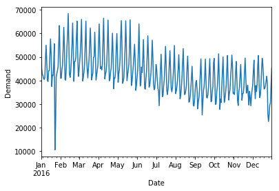

```python
# demand vs date
df['count'].plot()
plt.ylabel('Demand')
plt.show()
```

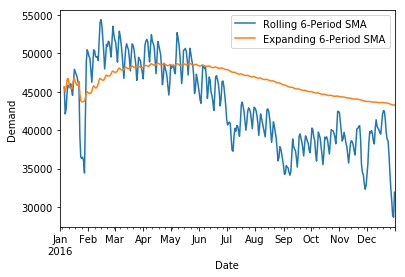

```python
df['count'].rolling(6).mean().plot()
df['count'].expanding(6).mean().plot()
plt.legend(('Rolling 6-Period SMA','Expanding 6-Period SMA'))
plt.ylabel('Demand')
plt.show()
```

#### From the Smoothening plot above, we could find that there is a relationship between season and taxi demand. Taxi demand is relatively high in spring. It shows a continous decreasing trend during the summer and keep lower during Fall and Winter.

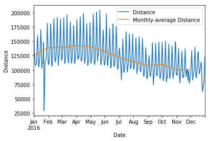

```python
#Season Vs average distance
df['Trip_distance'].plot()
df['Trip_distance'].resample('M').mean().plot()
plt.legend(('Distance','Monthly-average Distance'))
plt.ylabel('Distance')
plt.show()
```

#### From the graph above, we see that the average distance of trips is continuously decreasing from spring to winter, which is in accordance with the demand change pattern.

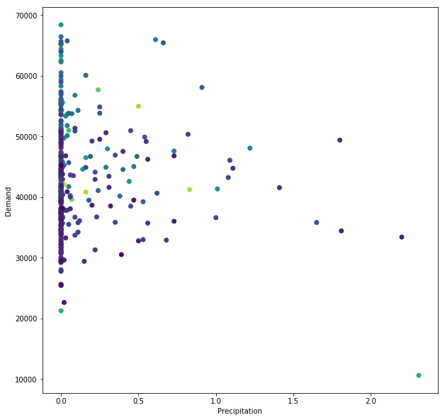

```python
# demand vs rain
z = list(reversed([i**3 for i in sorted(df['count'])]))
cmap = matplotlib.cm.get_cmap('viridis')
normalize = matplotlib.colors.Normalize(vmin=min(z), vmax=max(z))
colors = [cmap(normalize(value)) for value in z]
fig, ax = plt.subplots(figsize=(10,10))
plt.scatter(x=df['precipitation'],y=df['count'],color=colors)
plt.xlabel('Precipitation')
plt.ylabel('Demand')
plt.show()
```

#### From the scatter plot, raining doesn'affect the taxi demand very obviously.

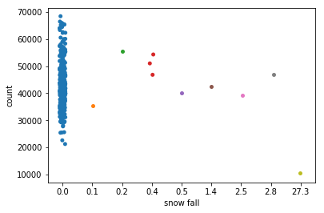

```python
# demand vs snow
sns.stripplot(x=df['snow fall'],y=df['count'])
```

#### There are only a few snowing day in the dataset. I can still find that if the snow is heavy, the taxi demand will decrease dramatically.

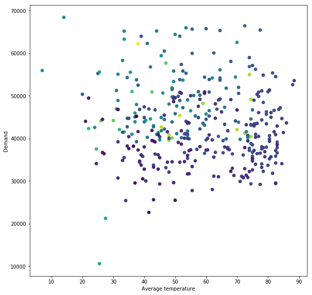

```python
# Demand vs avg temperature
z = list(reversed([i**3 for i in sorted(df['count'])]))
cmap = matplotlib.cm.get_cmap('viridis')
normalize = matplotlib.colors.Normalize(vmin=min(z), vmax=max(z))
colors = [cmap(normalize(value)) for value in z]
fig, ax = plt.subplots(figsize=(10,10))
plt.scatter(x=df['average temperature'],y=df['count'],color=colors)
plt.xlabel('Average temperature')
plt.ylabel('Demand')
plt.show()
```

#### No obvious relationship can be found between average temperature and taxi demand.

### How demand and average distance of trips change hourly?

```python
df=pd.read_csv('/Users/reggieyang/Desktop/Python/Python Project/Dataset/final dataset/taxi_hour_demand_weather.csv',index_col=[0])
df.head()
```

|  | Date | hour | Wind_km/h | Humidity_percentage | Temperature_c | Relative Temperature_c | weather | Trip_distance | Total_amount | count |
| --- | --- | --- | --- | --- | --- | --- | --- | --- | --- | --- |
| 0 | 2016-01-01 | 0 | 0 | 49 | 6 | 4 | Cloudy | 20092.80 | 96406.48 | 6264 |
| 1 | 2016-01-01 | 1 | 0 | 53 | 5 | 4 | Cloudy | 22829.77 | 108660.70 | 6639 |
| 2 | 2016-01-01 | 2 | 7 | 57 | 5 | 3 | Cloudy | 21530.42 | 101195.21 | 6134 |
| 3 | 2016-01-01 | 3 | 15 | 57 | 5 | 2 | Cloudy | 19203.65 | 88682.97 | 5467 |
| 4 | 2016-01-01 | 4 | 17 | 61 | 4 | 0 | Cloudy | 15129.00 | 70066.84 | 4520 |

#### Calculate mean values of trip distance and demand

```python
average_trip = df['Trip_distance']/df['count']
df['average_trip_distance_hour'] = average_trip
df_hourdemand = df[['hour','count']]
hour_count = df_hourdemand.groupby("hour",as_index=False).agg({'count':np.average})
```

#### Construct a barplot for the hourly damand change pattern

[output not shown]

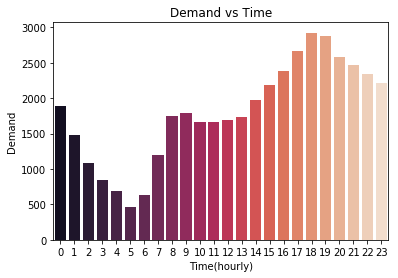

```python
x = hour_count['hour'].tolist()
y = hour_count['count'].tolist()
fig = sns.barplot(x=x,y=y, palette = 'rocket')
fig.set(xlabel='Time(hourly)', ylabel='Demand',title='Demand vs Time')
```

### Construct another barplot for the average trip distance pattern

[output not shown]

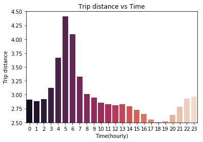

```python
hour_distance = df.groupby("hour",as_index=False).agg({'average_trip_distance_hour':np.average})
x1 = hour_distance['hour'].tolist()
y1 = hour_distance['average_trip_distance_hour'].tolist()
fig2 = sns.barplot(x=x1,y=y1, palette = 'rocket')
plt.ylim(2.5,4.5)
fig2.set(xlabel='Time(hourly)', ylabel='Trip distance',title='Trip distance vs Time')
```

#### From graph, the average distance per trip from 4am to 5am is much longer than other time period. Because the change shift of taxi drivers, taxi drivers would prefer to pickup passengers who are in for a long ride - it is more profitable for them. Therefore a higher distance covered in the shift hours is shown.

#### Second, the average distance per trip at evening rush hour is much shorter than trips at morning rush hour. We believe that different purposes of taxi result in the difference. In the morning rush hour, passengers always use taxi to commute and catch up early flight. The commute routes are relatively long trips, and going to the airport is also a long trip. In the evening rush hour, many taxi passengers go to dinner or entertainment, instead of returing home. Therefore, the average distance is much shorter than in the morning.

### 5. Demand distribution

### Which area shows a high demand in different time period?

```python
taxi_location = pd.read_csv('/Users/reggieyang/Desktop/Python/Python Project/Dataset/clean_location_taxi.csv')
taxi_location.info()
taxi_location = taxi_location[['lpep_pickup_datetime','Lpep_dropoff_datetime','Pickup_longitude','Pickup_latitude','Dropoff_longitude', 'Dropoff_latitude']]
taxi_location['lpep_pickup_datetime']=pd.to_datetime(taxi_location['lpep_pickup_datetime'],format='%m/%d/%Y %I:%M:%S %p')
taxi_location.set_index('lpep_pickup_datetime',inplace=True)
taxi_location.head()
```

```
<class 'pandas.core.frame.DataFrame'>
RangeIndex: 8712122 entries, 0 to 8712121
Data columns (total 21 columns):
Unnamed: 0               int64
VendorID                 int64
lpep_pickup_datetime     object
Lpep_dropoff_datetime    object
Store_and_fwd_flag       object
RateCodeID               int64
Pickup_longitude         float64
Pickup_latitude          float64
Dropoff_longitude        float64
Dropoff_latitude         float64
Passenger_count          int64
Trip_distance            float64
Fare_amount              float64
Extra                    float64
MTA_tax                  float64
Tip_amount               float64
Tolls_amount             float64
improvement_surcharge    float64
Total_amount             float64
Payment_type             int64
Trip_type                float64
dtypes: float64(13), int64(5), object(3)
memory usage: 1.4+ GB
```

| lpep_pickup_datetime | Lpep_dropoff_datetime | Pickup_longitude | Pickup_latitude | Dropoff_longitude | Dropoff_latitude |
| --- | --- | --- | --- | --- | --- |
| 2016-03-24 11:14:54 | 03/24/2016 11:20:54 AM | -73.953606 | 40.822086 | -73.960876 | 40.809982 |
| 2016-03-24 11:08:43 | 03/24/2016 11:14:18 AM | -73.966606 | 40.804276 | -73.974014 | 40.791592 |
| 2016-03-24 11:26:11 | 03/24/2016 11:42:36 AM | -73.966530 | 40.804249 | -73.939430 | 40.805172 |
| 2016-03-24 11:45:05 | 03/24/2016 11:55:36 AM | -73.936951 | 40.804123 | -73.872467 | 40.774296 |
| 2016-03-24 11:01:44 | 03/24/2016 11:09:00 AM | -73.938347 | 40.796387 | -73.949059 | 40.794273 |

#### 5.1 Weekday Demand Distribution

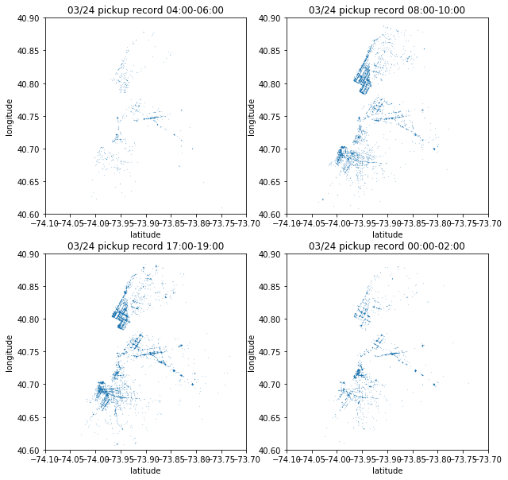

```python
#analysis working day pickup distribution(2016/03/24)
taxi_location_324 = taxi_location['2016-03-24']
#split the datetime to 4 parts: midnight (23:00-5:00) morning (6:00-11:00) afternoon(12:00-17:00) evening(17:00-23:00)
taxi_location_324_midnight=taxi_location_324['2016-03-24 04':'2016-03-24 05']
taxi_location_324_morning=taxi_location_324['2016-03-24 08':'2016-03-24 09']
taxi_location_324_afternoon=taxi_location_324['2016-03-24 17':'2016-03-24 18']
taxi_location_324_evening=taxi_location_324['2016-03-24 00':'2016-03-24 01']

#visulizing data
#extract longitude and latitude
import matplotlib.pyplot as plt
longitude1 = list(taxi_location_324_midnight.Pickup_longitude)
latitude1 = list(taxi_location_324_midnight.Pickup_latitude)
longitude2 = list(taxi_location_324_morning.Pickup_longitude)
latitude2 = list(taxi_location_324_morning.Pickup_latitude)
longitude3 = list(taxi_location_324_afternoon.Pickup_longitude)
latitude3 = list(taxi_location_324_afternoon.Pickup_latitude)
longitude4 = list(taxi_location_324_evening.Pickup_longitude)
latitude4 = list(taxi_location_324_evening.Pickup_latitude)
plt.figure(figsize = (10,10))
#subplot graph
plt.subplot(2,2,1)
plt.xlim(-74.1,-73.7)
plt.ylim(40.6,40.9)
plt.xlabel('latitude')
plt.ylabel('longitude')
plt.title('03/24 pickup record 04:00-06:00')
plt.plot(longitude1,latitude1,'.', alpha = 1, markersize = 0.2)

plt.subplot(2,2,2)
plt.xlim(-74.1,-73.7)
plt.ylim(40.6,40.9)
plt.xlabel('latitude')
plt.ylabel('longitude')
plt.title('03/24 pickup record 08:00-10:00')
plt.plot(longitude2,latitude2,'.', alpha = 1, markersize = 0.2)

plt.subplot(2,2,3)
plt.xlim(-74.1,-73.7)
plt.ylim(40.6,40.9)
plt.xlabel('latitude')
plt.ylabel('longitude')
plt.title('03/24 pickup record 17:00-19:00')
plt.plot(longitude3,latitude3,'.', alpha = 1, markersize = 0.2)

plt.subplot(2,2,4)
plt.xlim(-74.1,-73.7)
plt.ylim(40.6,40.9)
plt.xlabel('latitude')
plt.ylabel('longitude')
plt.title('03/24 pickup record 00:00-02:00')
plt.plot(longitude4,latitude4,'.', alpha = 1, markersize = 0.2)

plt.show()
```

#### Another interesting thing we could find from these graphs is that the market demand is always higher at night commute time than the demand at morning commute time. By analyzing customer behavior and reading some interesting materials we could find several reasons for this phenomenon. Firstly, not everybody goes to office on time during the morning time, but they will leave office on time together at night commute time. Secondly, the most of morning pickup is going to work or school. Night time is different, most of pick up is going to dinner, event, theater, and parties.

#### 5.2 Holiday Demand Distribution

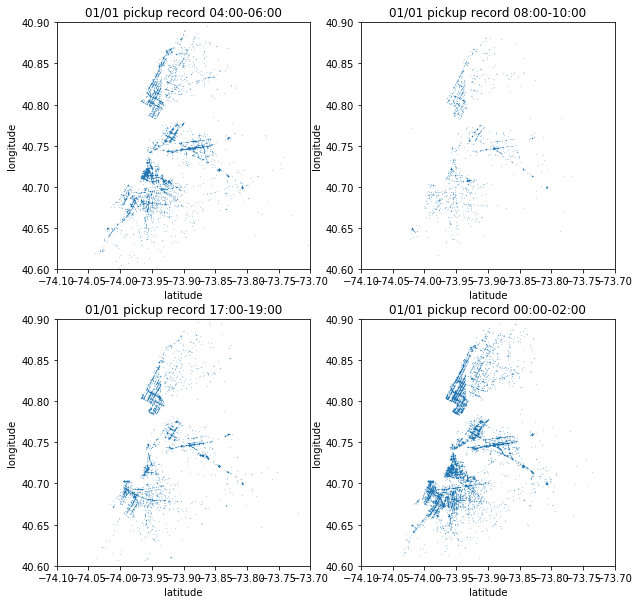

```python
#analysis new year pickup distribution(2016/01/01)
taxi_location_0101 = taxi_location['2016-01-01']
taxi_location_0101['2016-01-01'].shape
#split the datetime to 4 parts: midnight (23:00-5:00) morning (6:00-11:00) afternoon(12:00-17:00) evening(17:00-23:00)
taxi_location_0101_midnight=taxi_location_0101['2016-01-01 04':'2016-01-01 05']
taxi_location_0101_morning=taxi_location_0101['2016-01-01 08':'2016-01-01 09']
taxi_location_0101_afternoon=taxi_location_0101['2016-01-01 17':'2016-01-01 18']
taxi_location_0101_evening=taxi_location_0101['2016-01-01 00':'2016-01-01 01']

#extract longitude and latitude
import matplotlib.pyplot as plt
longitude1 = list(taxi_location_0101_midnight.Pickup_longitude)
latitude1 = list(taxi_location_0101_midnight.Pickup_latitude)
longitude2 = list(taxi_location_0101_morning.Pickup_longitude)
latitude2 = list(taxi_location_0101_morning.Pickup_latitude)
longitude3 = list(taxi_location_0101_afternoon.Pickup_longitude)
latitude3 = list(taxi_location_0101_afternoon.Pickup_latitude)
longitude4 = list(taxi_location_0101_evening.Pickup_longitude)
latitude4 = list(taxi_location_0101_evening.Pickup_latitude)
plt.figure(figsize = (10,10))
#subplot graph
plt.subplot(2,2,1)
plt.xlim(-74.1,-73.7)
plt.ylim(40.6,40.9)
plt.xlabel('latitude')
plt.ylabel('longitude')
plt.title('01/01 pickup record 04:00-06:00')
plt.plot(longitude1,latitude1,'.', alpha = 1, markersize = 0.2)

plt.subplot(2,2,2)
plt.xlim(-74.1,-73.7)
plt.ylim(40.6,40.9)
plt.xlabel('latitude')
plt.ylabel('longitude')
plt.title('01/01 pickup record 08:00-10:00')
plt.plot(longitude2,latitude2,'.', alpha = 1, markersize = 0.2)

plt.subplot(2,2,3)
plt.xlim(-74.1,-73.7)
plt.ylim(40.6,40.9)
plt.xlabel('latitude')
plt.ylabel('longitude')
plt.title('01/01 pickup record 17:00-19:00')
plt.plot(longitude3,latitude3,'.', alpha = 1, markersize = 0.2)

plt.subplot(2,2,4)
plt.xlim(-74.1,-73.7)
plt.ylim(40.6,40.9)
plt.xlabel('latitude')
plt.ylabel('longitude')
plt.title('01/01 pickup record 00:00-02:00')
plt.plot(longitude4,latitude4,'.', alpha = 1, markersize = 0.2)

plt.show()
```

#### Holiday graph:

#### In addition to the weekday pickup distribution, we also analyzed the pickup distribution on New Year’s Day as an example for holiday case. Unlike the weekday distribution, the market demand still shows a relatively high level at midnight and early morning time on New Year’s Day. The market demand is lowest at the morning commute time. For driver perspective, these graphs can give them an idea about holiday pickup distribution, which can help them a lot to decide working hours and pickup area.

#### 5.3 Geographic map (pickup & dropoff analysis)

##### 5.3.1 pickup geographic map

```python
import folium
#set default map
map_1 = folium.Map(location=[40.767937,-73.922155 ],tiles='OpenStreetMap',
 zoom_start=11)
#show first 1000 records
for each in taxi_raw[:1000].iterrows():
    folium.CircleMarker([each[1]['Pickup_latitude'],each[1]['Pickup_longitude']],
                        radius=2,
                        color='red',
                        popup=str(each[1]['Pickup_latitude'])+','+str(each[1]['Pickup_longitude']),
                        fill_color='#FD8A6C'
                        ).add_to(map_1)
map_1
```

[interactive chart not shown]

### Which area is the most popular destination?

##### 5.3.2 dropoff geographic map

```python
#set default map
map_2 = folium.Map(location=[40.767937,-73.922155 ],tiles='OpenStreetMap',
 zoom_start=11)
#iterate first 1000 records
for each in taxi_raw[:1000].iterrows():
    folium.CircleMarker([each[1]['Dropoff_latitude'],each[1]['Dropoff_longitude']],
                        radius=2,
                        color='blue',
                        popup=str(each[1]['Dropoff_latitude'])+','+str(each[1]['Dropoff_longitude']),
                        fill_color='#FD8A6C'
                        ).add_to(map_2)
map_2
```

[interactive chart not shown]

#### The two graphs above only contains first 1000 rows in the dataset. The red datapoints show the pickup records; the blue datapoints show the dropoff records.

#### There is no doubt that Manhattan has no datapoint in pickup graph because of the limitation of green cab in NYC. Therefore, we cannot find direct evidence of demand of Manhattan. However, from drop-off graph, we can see that Manhattan has one of the densest datapoint in NYC, which means a lot of passengers’ destination is Manhattan. Thus, the demand of Manhattan and nearby district should be high too.

## 6. Weekly Revenue Analysis

### What is the trend of weekly revenue in 2016?

```python
#read taxi_fare data
taxi_fare = pd.read_csv('/Users/reggieyang/Desktop/Python/Python Project/Dataset/2016_Green_Taxi_Trip_Data.csv')
#drop any ourliers
taxi_fare = taxi_fare[taxi_fare['Total_amount']>0]
taxi_fare = taxi_fare[taxi_fare['Tolls_amount']>=0]
taxi_fare = taxi_fare[taxi_fare['Tip_amount']>=0]
taxi_fare = taxi_fare[taxi_fare['Fare_amount']>=0]
taxi_fare = taxi_fare[taxi_fare['Trip_distance']>0]
taxi_fare = taxi_fare[taxi_fare['Passenger_count']<=5]
#slice the data
taxi_fare=taxi_fare[['lpep_pickup_datetime','Total_amount']]
#set datetime to index
taxi_fare['lpep_pickup_datetime']=pd.to_datetime(taxi_fare['lpep_pickup_datetime'],format='%m/%d/%Y %I:%M:%S %p')
taxi_fare.set_index('lpep_pickup_datetime',inplace=True)
taxi_fare.head()
```

| lpep_pickup_datetime | Total_amount |
| --- | --- |
| 2016-03-24 11:14:54 | 8.16 |
| 2016-03-24 11:08:43 | 6.80 |
| 2016-03-24 11:26:11 | 14.80 |
| 2016-03-24 11:45:05 | 24.84 |
| 2016-03-24 11:01:44 | 7.30 |

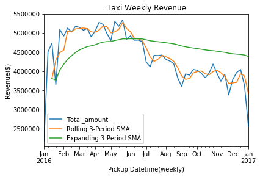

```python
#resample pickup datetime to weekly, and plot the data
taxi_fare['Total_amount'].resample('W').sum().plot()
taxi_fare['Total_amount'].resample('W').sum().rolling(3).mean().plot()
taxi_fare['Total_amount'].resample('W').sum().expanding(3).mean().plot()
plt.legend(('Total_amount','Rolling 3-Period SMA','Expanding 3-Period SMA'))
plt.title('Taxi Weekly Revenue')
plt.xlabel('Pickup Datetime(weekly)')
plt.ylabel('Revenue($)')
plt.show()
```

## 7. Conclusion

#### 1. How weather impacts taxi demand?

- NYC taxi demand has a continuous-slow decreasing trend from spring to winter, where average distance of trips has the same trend. Due to limitation of the dataset, we cannot find persuasive influences of precipitation, snow-depth and average temperature on the NYC taxi demand pattern. ##### Q1 Takeaway:
  - Both taxi drivers and customers may worry about the bad influence caused by inclement weather on their travel and business. Although there is not an obvious relationship between raining factors and taxi demand, taxi drivers should still pay attention to heavy snow day. The snow day observations are limited in our dataset, but we could find that the taxi demand dropped dramatically in a heavy snow day. People who want to go outside by taxi should also pay attention to this, because they might not find any taxi available to pick up them in such a heavy snow day.